# Problema 1 - Checkpoint 1

Luiza Carvalho

22 de maio de 2017

```r
library(tidyverse, warn.conflicts = F)
library(dplyr)
library(ggplot2)
```

## Descrevendo os Dados

O conjunto de dados que está sendo utilizado é composto por séries, nos dados estão: o nome da série, o número de cada episódio, a que temporada ele pertence, seu número na temporada, sua url para a página no IMDB, o nome do episódio, sua nota individual e o número de votações de usuários, também por episódio, todas essas informações estão disponíveis no IMDB. Nem todas as informações que estão no conjunto de dados serão utilizadas nessa análise, as variáveis que são o foco deste estudo são os nomes das séries e suas notas por episódio. As séries utilizadas no conjunto de dados original e os nomes das variáveis descritas acima são:

```r
# importando os dados
dados <- read.csv('series_from_imdb.csv')

#séries
unique(dados$series_name)
```

```
##  [1] 13 Reasons Why              How to Get Away with Murder
##  [3] Mr Robot                    Sense8
##  [5] Sherlock                    Black Mirror
##  [7] Breaking Bad                Dexter
##  [9] House of Cards              Stranger Things
## [11] Arrow                       Gotham
## [13] Greyâs Anatomy            The 100
## [15] Agents of S.H.I.E.L.D.      Daredevil
## [17] Flash                       Once Upon a Time
## [19] Friends                     Prison Break
## [21] The Blacklist               Homeland
## [23] How I Met Your Mother       The Simpsons
## [25] Game of Thrones             Orphan Black
## [27] Scandal                     The Walking Dead
## [29] Modern Family               Narcos
## [31] Vikings
## 31 Levels: 13 Reasons Why Agents of S.H.I.E.L.D. Arrow ... Vikings
```

```r
# variáveis
names(dados)
```

```
##  [1] "series_name" "series_ep"   "season"      "season_ep"   "url"
##  [6] "Episode"     "UserRating"  "UserVotes"   "r1"          "r10"
## [11] "r2"          "r3"          "r4"          "r5"          "r6"
## [16] "r7"          "r8"          "r9"
```

A amostra que será utilizada é de 4 seriados escolhidos de maneira aleatória, eles são Orphan Black, The 100, Stranger Things e Once Upon a Time.

```r
# selecionando as séries que serão utilizadas
dados <- dados %>% filter(series_name %in% c("Once Upon a Time", "The 100", "Orphan Black", "Stranger Things"))
```

## Melhor Avaliação

1. Qual das séries que você escolheu é mais bem avaliada no IMDB? A diferença é grande? Pequena?

Para descobrir qual das séries escolhidas é mais bem avaliada no IMDB será analisado o valor da mediana das notas de cada série. Pois a mediana é o valor que separa a metade maior e a metade menor da amostra, portanto, uma série com mediana maior que 8, por exemplo, terá 50% dos seus episódios com notas maiores do que 8, enquanto uma série com mediana 7 terá 50% dos episódios com notas maiores que 7. Desse modo temos que a série de mediana 8 seria mais bem avaliada do que uma com mediana com o valor 7.

Além disso, a mediana foi escolhida pois não é tão distorcida por valores extremamente altos ou baixos, se fosse escolhida a média para descobrir a maior avaliação do IMDB nessa amostra uma série que possui 10 episódios apenas e um deles com uma nota muito baixa, digamos 2, estaria em desvantagem ao ser comparada a uma série com 100 episódios com apenas um deles tendo nota 2 também, porque a média da primeira série seria distorcida pelo valor baixo. Enquanto isso a mediana nos informa que 50% dos episódios possuem nota acima de x, portanto é mais justa quando avaliamos seriados com números de episódios diferentes.

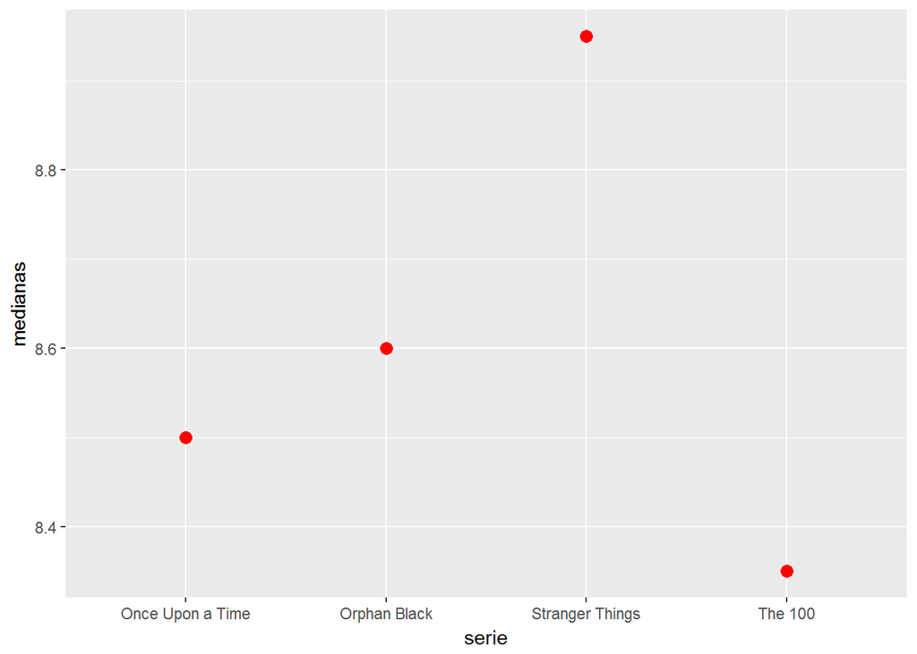

```r
# separando os dados por série
ob <- dados %>% filter(series_name %in% c("Orphan Black"))
ouat <- dados %>% filter(series_name %in% c("Once Upon a Time"))
t100 <- dados %>% filter(series_name %in% c("The 100"))
st <- dados %>% filter(series_name %in% c("Stranger Things"))

# calculando as medianas e criando data frame para elas

medianas <- c(median(ouat$UserRating),median(t100$UserRating),median(ob$UserRating),median(st$UserRating))

serie <- c("Once Upon a Time", "The 100", "Orphan Black", "Stranger Things")

series.medianas <- data.frame(serie,medianas)

series.medianas %>% ggplot(aes(x= serie , y = medianas)) + geom_point(size = 3, color = 'red')
```

```r
show(series.medianas)
```

```
##              serie medianas
## 1 Once Upon a Time     8.50
## 2          The 100     8.35
## 3     Orphan Black     8.60
## 4  Stranger Things     8.95
```

Como pode ser observado, tanto no gráfico como na matriz, Stranger Things é a série mais bem avaliada pelo IMDB da amostra. A diferença entre as medianas das séries não é tão grande, sendo a com pior avaliação (The 100) 8.35 e a melhor (Stranger Things) 8.95, sua diferença é de apenas 6 décimos.

## Qualidade Irregular

2. Qual das séries que você escolheu tem episódios de qualidade mais irregular segundo o IMDB? A diferença é grande? Pequena?

Para determinar se há irregularidade na qualidade das séries será utilizado o boxplot, com ele é possível analisar se há uma grande variância (uma medida de dispersão que mostra quão distantes os valores estão da média) entre as notas de cada episódio, quanto maior a variância, maior o boxplot e mais irregular uma série é.

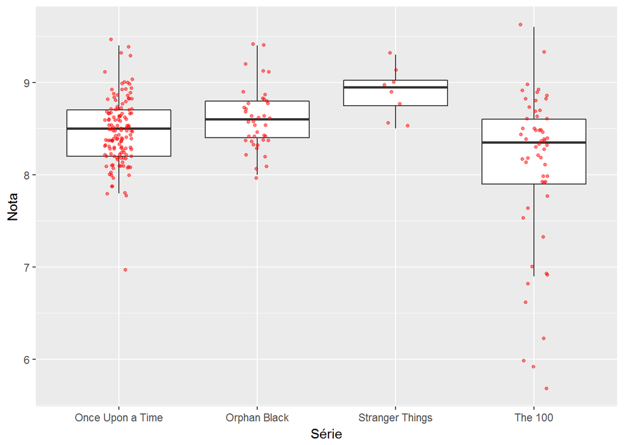

```r
dados %>%
  ggplot(aes(x = series_name,y = UserRating)) + geom_boxplot(outlier.color = NA) + labs( x= "Série", y= "Nota") + geom_jitter(width = .1, size = 1, alpha = .5, color = "red")
```

Podemos observar pelos boxplots e pela distribuição de notas por episódio em formato de pontos nos gráficos, que The 100 é a série com maior irregularidade entre a qualidade dos seus episódios, ela possui uma variância significante entre as notas dos seus episódios, tendo também o maior pico positivo e o menor pico negativo entre as séries escolhidas.

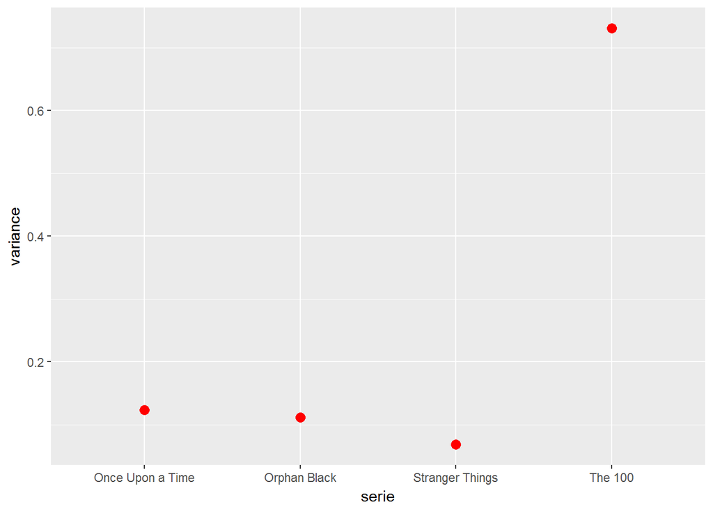

```r
# criando um data frame para as variancias

variance <- c(var(ouat$UserRating),var(t100$UserRating),var(ob$UserRating),var(st$UserRating))

variancia <- data.frame(serie,variance)

variancia %>% ggplot(aes(x= serie , y = variance)) + geom_point(size = 3, color = 'red')
```

```r
show(variancia)
```

```
##              serie   variance
## 1 Once Upon a Time 0.12345479
## 2          The 100 0.73069805
## 3     Orphan Black 0.11153205
## 4  Stranger Things 0.06857143
```

Como é possível observar no gráfico e na matriz que mostra as variancias, a diferença entre a qualidade dos episódios de cada série é razoável. Stranger Things possui a menor variância de qualidade, Orphan Black e Once Upon a Time variâncias semelhantes, no entanto Once Upon a Time é um pouco mais irregular, e The 100 possui a maior irregularidade de todas.